# Impact of weather events on public health and economy

## SYNOPSIS

Based on the U.S. National Oceanic and Atmospheric Administration’s (NOAA) storm database we answered 2 questions: 1. Across the United States, which types of events (as indicated in the EVTYPE variable) are most harmful with respect to population health? 2.Across the United States, which types of events have the greatest economic consequences?

The results point out that 3 main types of events out of 50 are the most harmful for US population health and economy respectively:

1. Concerning Population Heath in terms of Injuries: Tornados (by fare), Floods and Excessive heats.
2. Concerning Population Heath in terms of Deaths: Excessive Heats, Tornados and Heat.
3. Concerning Economic consequences: Floods (by fare), Hurricanes and Flash Floods.

## DATA PROCESSING

### downloading and extracting data

The zip file is downloaded from the website and stored on the disk in a folder called “Storm”.

Data set is stored into R in “data”

```r
dataa<-read.csv("Storm/data.bz2")
head(dataa)
```

```
##   STATE__           BGN_DATE BGN_TIME TIME_ZONE COUNTY COUNTYNAME STATE
## 1       1  4/18/1950 0:00:00     0130       CST     97     MOBILE    AL
## 2       1  4/18/1950 0:00:00     0145       CST      3    BALDWIN    AL
## 3       1  2/20/1951 0:00:00     1600       CST     57    FAYETTE    AL
## 4       1   6/8/1951 0:00:00     0900       CST     89    MADISON    AL
## 5       1 11/15/1951 0:00:00     1500       CST     43    CULLMAN    AL
## 6       1 11/15/1951 0:00:00     2000       CST     77 LAUDERDALE    AL
##    EVTYPE BGN_RANGE BGN_AZI BGN_LOCATI END_DATE END_TIME COUNTY_END
## 1 TORNADO         0                                               0
## 2 TORNADO         0                                               0
## 3 TORNADO         0                                               0
## 4 TORNADO         0                                               0
## 5 TORNADO         0                                               0
## 6 TORNADO         0                                               0
##   COUNTYENDN END_RANGE END_AZI END_LOCATI LENGTH WIDTH F MAG FATALITIES
```

[output cut: 20 more lines]

### Cleaning Data

While doing exploratory analysis, one can observe that the raw data is some kind of messy.

1. As the NOAA shows in his document there should be only 50 events types. The data shows almost a thousand of unique types:

```r
length(unique(dataa$EVTYPE))
```

```
## [1] 985
```

2. the data for years before 1995 seems not relevant enough, Hence, we subset the data like follows:

```r
datab<-dataa
datab$BGN_DATE<-as.Date(as.character(datab$BGN_DATE), format="%m/%d/%Y")
data<-subset(datab,datab$BGN_DATE>as.Date("1995-01-01"))
data$BGN_DATE<-as.Date(as.character(data$BGN_DATE), format="%Y%m/%d/ %H:%M:%S")
```

Using some basic patterns we can clean the data to higher the probability of a viable outcome.

```r
data1<-subset(data, data$FATALITIES!=0 | data$INJURIES!=0 | data$PROPDMG!=0 | data$CROPDMG!=0, select= c(EVTYPE,FATALITIES,INJURIES,PROPDMG,PROPDMGEXP,CROPDMG,CROPDMGEXP))

length(unique(data1$EVTYPE))
```

```
## [1] 372
```

```r
data1$EVTYPE<-sub("FLOOD.*","Flood",data1$EVTYPE)
data1$EVTYPE<-sub(".*TORNADO.*","Tornado",data1$EVTYPE)
data1$EVTYPE<-sub("HEAT.*","Heat",data1$EVTYPE)
data1$EVTYPE<-sub("HAIL.*","Hail",data1$EVTYPE)
data1$EVTYPE<-sub(".*TSTM.*","Thunderstrom Wind",data1$EVTYPE)
data1$EVTYPE<-sub(".*HURRICANE.*","hurricane",data1$EVTYPE)
data1$EVTYPE<-toupper(data1$EVTYPE)
length(unique(data1$EVTYPE))
```

```
## [1] 272
```

### Answering Question 1: Events and Health

To measure the impact of weather events on public health we look at: - the total number of Injuries (‘INJURIES’) or Deaths (‘FATALITIES’) caused by each respective event type (‘EVTYPE’).

Data set is subset and aggregate to show accurate data set (‘data2’)

```r
data2<-aggregate(cbind(INJURIES,FATALITIES)~EVTYPE, data=data1, FUN=sum, na.rm=TRUE)

head (data2)
```

```
##                   EVTYPE INJURIES FATALITIES
## 1     HIGH SURF ADVISORY        0          0
## 2            FLASH FLOOD        0          0
## 3    AGRICULTURAL FREEZE        0          0
## 4 ASTRONOMICAL HIGH TIDE        0          0
## 5  ASTRONOMICAL LOW TIDE        0          0
## 6              AVALANCHE      159        223
```

Looking at the data, one can see that a significant amount of events have caused few or no injuries and/or deaths. To answer the initial question we only select the top 7 events in terms of injuries and deaths caused respectively.

```r
data2.injuries<-data2[order(-data2$INJURIES),]
data2.injuries<-data2.injuries[1:7,]

data2.deaths<-data2[order(-data2$FATALITIES),]
data2.deaths<-data2.deaths[1:7,]
```

The dataset is used to create the final plots answering the question. (see result in RESULTS section below)

### Answering Question 2: Events and Material Damages (in $)

To measure the impact of weather events on the economy we look at: - the total number of damages in $ (‘PROPDMG’ and ‘CROPDMG’) caused by each respective event type (‘EVTYPE’).

The ‘PROPDMGEXP’ and ‘CROPDMGEXP’ columns are multipliers of the respective ‘PROPDMG’ and ‘CROPDMG’ column with: - “K” for thousands, - “M” for millions, - “B” for billions

Data set (‘data1’) is subset and aggregate to show accurate data set (‘data3’)

```r
multiplier<-function(X,Y){
  if (Y=="K"|Y=="k"){X<-X*10^3}
  if (Y=="M"|Y=="m"){X<-X*10^6}
  if (Y=="B"|Y=="b"){X<-X*10^9}
  if (Y=="H"|Y=="h"){X<-X*10^2}
  return (X)

  }
data3<-subset(data1, data1$PROPDMG!=0 & data1$CROPDMG!=0, select= c(EVTYPE,PROPDMG,PROPDMGEXP,CROPDMG,CROPDMGEXP))
data3$PROPDMG<-mapply(multiplier, data3$PROPDMG, data3$PROPDMGEXP)
data3<-subset(data3, select=c(EVTYPE,PROPDMG,CROPDMG))
data3<-aggregate(PROPDMG+CROPDMG~EVTYPE, data=data3, FUN=sum, na.rm=TRUE)
colnames(data3)<-c("EVTYPE","DAMAGES")
head(data3)
```

```
##           EVTYPE     DAMAGES
## 1       BLIZZARD   1700067.0
## 2        DROUGHT 232739001.0
## 3 DRY MICROBURST    114009.0
## 4     DUST STORM    790101.5
## 5 EXCESSIVE HEAT    170492.4
## 6   EXTREME COLD   2355506.8
```

In order to answer the initial question we only select the top 7 events in terms of global damages (Property and Crop damages).

```r
data.damages<-data3[order(-data3$DAMAGES),]
data.damages<-data.damages[1:7,]
```

## RESULTS

### Plot 1: Top 7 events in terms of injuries

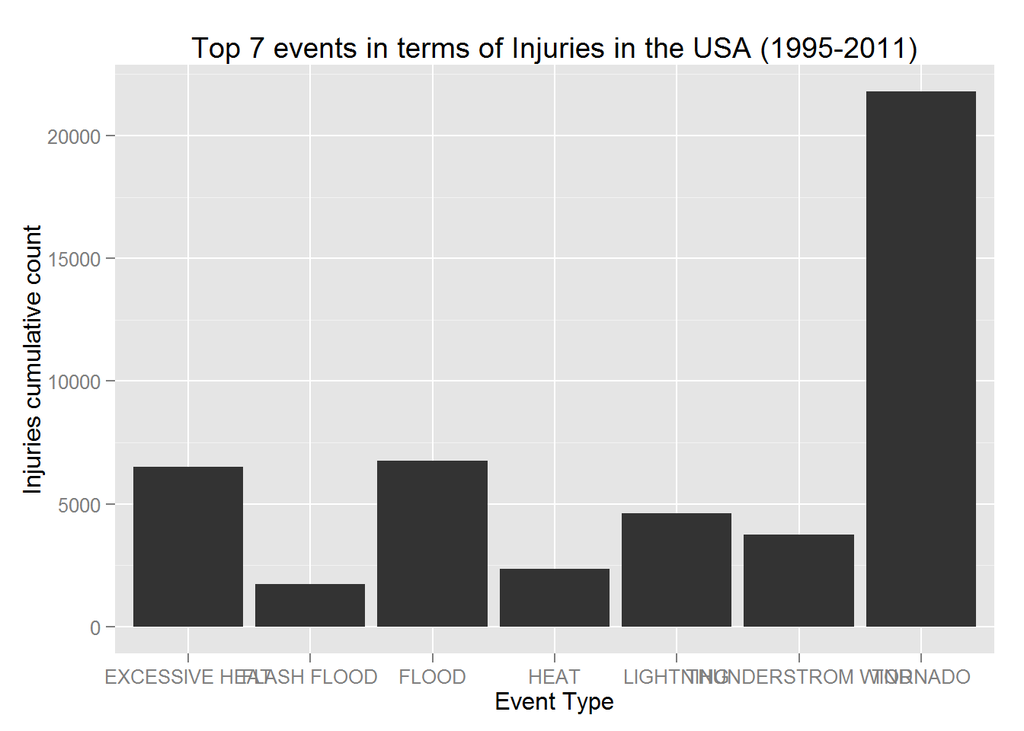

```r
library(ggplot2)
qplot(EVTYPE, data=data2.injuries, weight=INJURIES, geom="histogram", main="Top 7 events in terms of Injuries in the USA (1995-2011)", xlab="Event Type", ylab = "Injuries cumulative count")
```

### Plot 2: Top 7 events in terms of deaths

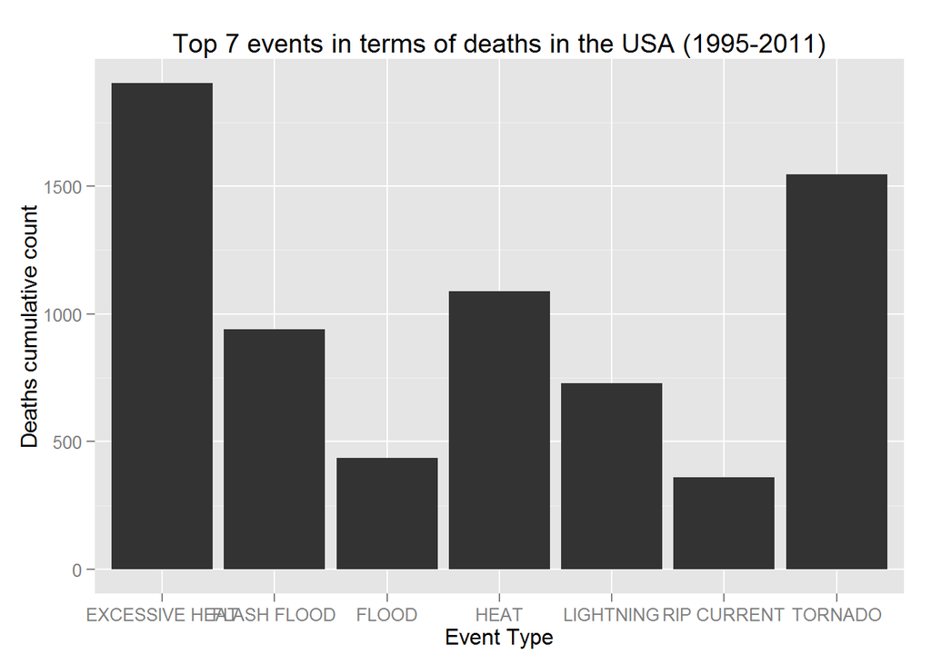

```r
qplot(EVTYPE, data=data2.deaths, weight=FATALITIES, geom="histogram", main="Top 7 events in terms of deaths in the USA (1995-2011)", xlab="Event Type", ylab = "Deaths cumulative count" )
```

### Answer 1:

As shown by those histograms we can see that Excessive Heats are the most harmful events for population health in terms of mortality and Tornados are most harmful events for population health in terms of injuries.

For mortality: Tornados comes next, followed by Heats and Flash floods. For Injuries: Floods comes next, followed by Excessive Heat.

### Plot 2: Top 7 events in terms of economy damages

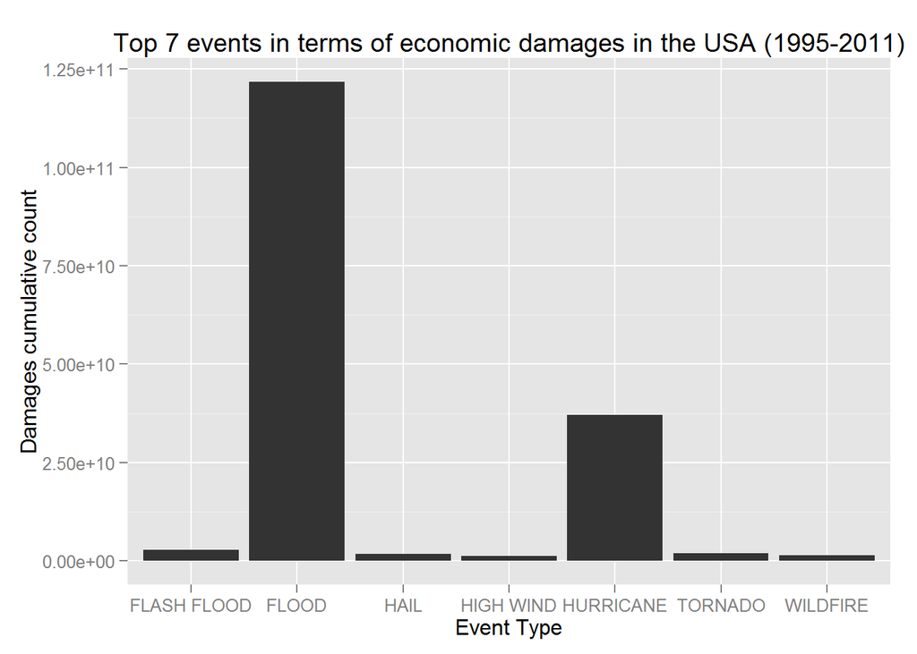

```r
library(ggplot2)
qplot(EVTYPE, data=data.damages, weight=DAMAGES, geom="histogram", main="Top 7 events in terms of economic damages in the USA (1995-2011)", xlab="Event Type", ylab = "Damages cumulative count")
```

### Answer 2:

As shown by this last histogram we can see that floods are by fare the most harmful events for the US economy.The damages caused by flood have 3 times more impact on US economy than Hurricanes, second. Third comes flash floods (floods that last less than 2 days).